[figure not shown]

# Predicting Home Prices:

## A Practical Data Science Workflow

**by Jackie Zuker**

We been provided various features of homes sold between 2006 and 2010 within the community of Ames, Iowa.

The Kaggle Challenge and supporting documentation can be found [here](https://www.kaggle.com/c/house-prices-advanced-regression-techniques/overview)

**Question of interest: How precisely can the sales price of a home be predicted?**

Before diving into the statistical analysis, let's get oriented to our dataset through some data exploration and visualization. First we see a histogram of the distribution of sales prices of the homes in the dataset.

# Data Exploration and Visualization

```python
# Import packages
import pandas as pd
import numpy as np
import matplotlib.pyplot as plt
import itertools
import seaborn as sns
import warnings

from sklearn import neighbors
from sklearn.model_selection import cross_val_score
from scipy import stats

# Set up matplotlib to display inline in Jupyter notebook
%matplotlib inline
sns.set_context("poster")

import warnings
warnings.filterwarnings('ignore')
```

```python
# Read in the data
homePricesTrain = pd.read_csv("data/train.csv")
print("Dimensions of homePricesTrain: ", homePricesTrain.shape)
homePricesTest = pd.read_csv("data/test.csv")
print("Dimensions of homePricesTest: ", homePricesTest.shape)

# Set the label of Sale Price to its own variable.
label = homePricesTrain['SalePrice']
homePricesTrain['Group'] = 'train'
homePricesTest['Group'] = 'test'

# Concatenate the test and training sets so that all feature engineering, data cleaning, etc is applied to both groups.
frames = [homePricesTrain, homePricesTest]
homePrices = pd.concat(frames, sort = False)
homePricesPCA = homePrices


homePrices.head(30)
```

```
Dimensions of homePricesTrain:  (1460, 81)
Dimensions of homePricesTest:  (1459, 80)
```

|  | Id | MSSubClass | MSZoning | LotFrontage | LotArea | Street | Alley | LotShape | LandContour | Utilities | ... | PoolQC | Fence | MiscFeature | MiscVal | MoSold | YrSold | SaleType | SaleCondition | SalePrice | Group |
| --- | --- | --- | --- | --- | --- | --- | --- | --- | --- | --- | --- | --- | --- | --- | --- | --- | --- | --- | --- | --- | --- |
| 0 | 1 | 60 | RL | 65.0 | 8450 | Pave | NaN | Reg | Lvl | AllPub | ... | NaN | NaN | NaN | 0 | 2 | 2008 | WD | Normal | 208500.0 | train |
| 1 | 2 | 20 | RL | 80.0 | 9600 | Pave | NaN | Reg | Lvl | AllPub | ... | NaN | NaN | NaN | 0 | 5 | 2007 | WD | Normal | 181500.0 | train |
| 2 | 3 | 60 | RL | 68.0 | 11250 | Pave | NaN | IR1 | Lvl | AllPub | ... | NaN | NaN | NaN | 0 | 9 | 2008 | WD | Normal | 223500.0 | train |
| 3 | 4 | 70 | RL | 60.0 | 9550 | Pave | NaN | IR1 | Lvl | AllPub | ... | NaN | NaN | NaN | 0 | 2 | 2006 | WD | Abnorml | 140000.0 | train |
| 4 | 5 | 60 | RL | 84.0 | 14260 | Pave | NaN | IR1 | Lvl | AllPub | ... | NaN | NaN | NaN | 0 | 12 | 2008 | WD | Normal | 250000.0 | train |
| 5 | 6 | 50 | RL | 85.0 | 14115 | Pave | NaN | IR1 | Lvl | AllPub | ... | NaN | MnPrv | Shed | 700 | 10 | 2009 | WD | Normal | 143000.0 | train |
| 6 | 7 | 20 | RL | 75.0 | 10084 | Pave | NaN | Reg | Lvl | AllPub | ... | NaN | NaN | NaN | 0 | 8 | 2007 | WD | Normal | 307000.0 | train |
| 7 | 8 | 60 | RL | NaN | 10382 | Pave | NaN | IR1 | Lvl | AllPub | ... | NaN | NaN | Shed | 350 | 11 | 2009 | WD | Normal | 200000.0 | train |
| 8 | 9 | 50 | RM | 51.0 | 6120 | Pave | NaN | Reg | Lvl | AllPub | ... | NaN | NaN | NaN | 0 | 4 | 2008 | WD | Abnorml | 129900.0 | train |
| 9 | 10 | 190 | RL | 50.0 | 7420 | Pave | NaN | Reg | Lvl | AllPub | ... | NaN | NaN | NaN | 0 | 1 | 2008 | WD | Normal | 118000.0 | train |
| 10 | 11 | 20 | RL | 70.0 | 11200 | Pave | NaN | Reg | Lvl | AllPub | ... | NaN | NaN | NaN | 0 | 2 | 2008 | WD | Normal | 129500.0 | train |
| 11 | 12 | 60 | RL | 85.0 | 11924 | Pave | NaN | IR1 | Lvl | AllPub | ... | NaN | NaN | NaN | 0 | 7 | 2006 | New | Partial | 345000.0 | train |
| 12 | 13 | 20 | RL | NaN | 12968 | Pave | NaN | IR2 | Lvl | AllPub | ... | NaN | NaN | NaN | 0 | 9 | 2008 | WD | Normal | 144000.0 | train |
| 13 | 14 | 20 | RL | 91.0 | 10652 | Pave | NaN | IR1 | Lvl | AllPub | ... | NaN | NaN | NaN | 0 | 8 | 2007 | New | Partial | 279500.0 | train |
| 14 | 15 | 20 | RL | NaN | 10920 | Pave | NaN | IR1 | Lvl | AllPub | ... | NaN | GdWo | NaN | 0 | 5 | 2008 | WD | Normal | 157000.0 | train |
| 15 | 16 | 45 | RM | 51.0 | 6120 | Pave | NaN | Reg | Lvl | AllPub | ... | NaN | GdPrv | NaN | 0 | 7 | 2007 | WD | Normal | 132000.0 | train |
| 16 | 17 | 20 | RL | NaN | 11241 | Pave | NaN | IR1 | Lvl | AllPub | ... | NaN | NaN | Shed | 700 | 3 | 2010 | WD | Normal | 149000.0 | train |
| 17 | 18 | 90 | RL | 72.0 | 10791 | Pave | NaN | Reg | Lvl | AllPub | ... | NaN | NaN | Shed | 500 | 10 | 2006 | WD | Normal | 90000.0 | train |
| 18 | 19 | 20 | RL | 66.0 | 13695 | Pave | NaN | Reg | Lvl | AllPub | ... | NaN | NaN | NaN | 0 | 6 | 2008 | WD | Normal | 159000.0 | train |
| 19 | 20 | 20 | RL | 70.0 | 7560 | Pave | NaN | Reg | Lvl | AllPub | ... | NaN | MnPrv | NaN | 0 | 5 | 2009 | COD | Abnorml | 139000.0 | train |
| 20 | 21 | 60 | RL | 101.0 | 14215 | Pave | NaN | IR1 | Lvl | AllPub | ... | NaN | NaN | NaN | 0 | 11 | 2006 | New | Partial | 325300.0 | train |
| 21 | 22 | 45 | RM | 57.0 | 7449 | Pave | Grvl | Reg | Bnk | AllPub | ... | NaN | GdPrv | NaN | 0 | 6 | 2007 | WD | Normal | 139400.0 | train |
| 22 | 23 | 20 | RL | 75.0 | 9742 | Pave | NaN | Reg | Lvl | AllPub | ... | NaN | NaN | NaN | 0 | 9 | 2008 | WD | Normal | 230000.0 | train |
| 23 | 24 | 120 | RM | 44.0 | 4224 | Pave | NaN | Reg | Lvl | AllPub | ... | NaN | NaN | NaN | 0 | 6 | 2007 | WD | Normal | 129900.0 | train |
| 24 | 25 | 20 | RL | NaN | 8246 | Pave | NaN | IR1 | Lvl | AllPub | ... | NaN | MnPrv | NaN | 0 | 5 | 2010 | WD | Normal | 154000.0 | train |
| 25 | 26 | 20 | RL | 110.0 | 14230 | Pave | NaN | Reg | Lvl | AllPub | ... | NaN | NaN | NaN | 0 | 7 | 2009 | WD | Normal | 256300.0 | train |
| 26 | 27 | 20 | RL | 60.0 | 7200 | Pave | NaN | Reg | Lvl | AllPub | ... | NaN | NaN | NaN | 0 | 5 | 2010 | WD | Normal | 134800.0 | train |
| 27 | 28 | 20 | RL | 98.0 | 11478 | Pave | NaN | Reg | Lvl | AllPub | ... | NaN | NaN | NaN | 0 | 5 | 2010 | WD | Normal | 306000.0 | train |
| 28 | 29 | 20 | RL | 47.0 | 16321 | Pave | NaN | IR1 | Lvl | AllPub | ... | NaN | NaN | NaN | 0 | 12 | 2006 | WD | Normal | 207500.0 | train |
| 29 | 30 | 30 | RM | 60.0 | 6324 | Pave | NaN | IR1 | Lvl | AllPub | ... | NaN | NaN | NaN | 0 | 5 | 2008 | WD | Normal | 68500.0 | train |

30 rows × 82 columns

[figure not shown]

## Distribution of Sale Prices

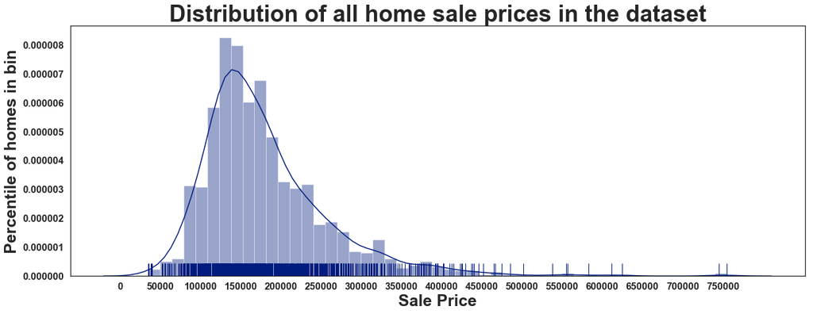

```python
# Histogram of home prices
sns.set(style="white", palette="dark")
plt.figure(figsize=(20,7))
sns.distplot(homePricesTrain["SalePrice"], kde=True, rug=True);
plt.title("Distribution of all home sale prices in the dataset", size = 35, fontweight = "bold")
plt.xlabel("Sale Price", size = 25, fontweight = "bold")
plt.ylabel("Percentile of homes in bin", size = 25, fontweight = "bold")
plt.xticks(np.arange(0, max(homePricesTrain["SalePrice"])+1000, 50000), size=15, fontweight = "bold")
plt.yticks(size = 15, fontweight = "bold")
plt.show()
```

## Neighborhood

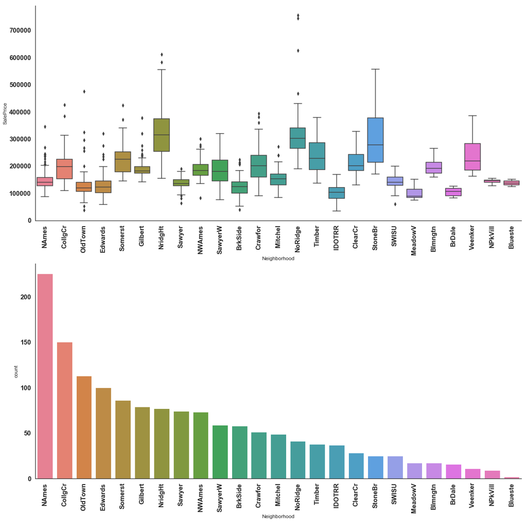

```python
fig, (ax1,ax2) = plt.subplots(2, figsize=(20,20))
sns.despine(left=False)

sns.boxplot("Neighborhood","SalePrice",data=homePricesTrain, order=homePricesTrain.Neighborhood.value_counts().index, palette="husl", ax=ax1)
sns.countplot(x="Neighborhood", data=homePricesTrain, order=homePricesTrain.Neighborhood.value_counts().index, palette="husl", ax=ax2)
for ax in fig.axes:
    plt.sca(ax)
    plt.xticks(rotation=90, size = 15, fontweight = "bold")
    plt.yticks(size = 15, fontweight = "bold")

plt.show()
```

## Home Prices

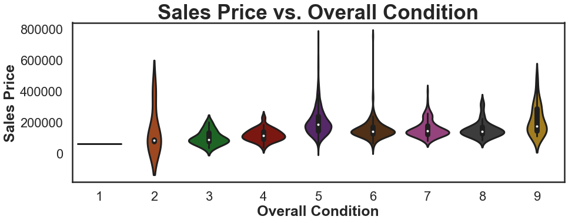

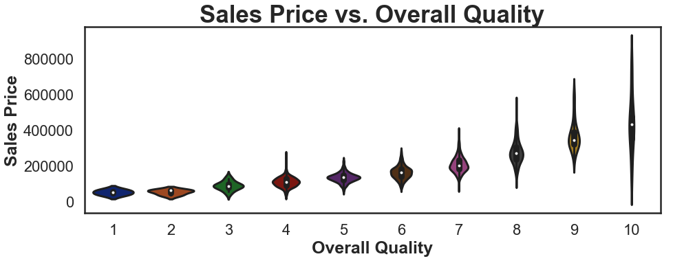

```python
sns.set_context("poster")

sns.despine(trim = True)
plt.figure(figsize=(15,5))
sns.violinplot("OverallCond","SalePrice",data = homePricesTrain)
plt.title("Sales Price vs. Overall Condition", size = 35, fontweight = "bold")
plt.xlabel("Overall Condition", size = 25, fontweight = "bold")
plt.ylabel("Sales Price", size = 25, fontweight = "bold")


plt.figure(figsize=(15,5))
sns.violinplot("OverallQual","SalePrice",data = homePricesTrain)
plt.title("Sales Price vs. Overall Quality", size = 35, fontweight = "bold")

plt.ylabel("Sales Price", size = 25, fontweight = "bold")
plt.xlabel("Overall Quality", size = 25, fontweight = "bold")
plt.show()
```

# Data Cleaning

Missing Value Imputation:

The first step is to address any missing values. The following variables have more than 15% of the values missing or NaN.

```python
del homePrices["SalePrice"]

nans = pd.isnull(homePrices).sum()
missing = nans[nans>(len(homePrices)*.15)]
missing = list(missing.index)
print(missing)
```

```
['LotFrontage', 'Alley', 'FireplaceQu', 'PoolQC', 'Fence', 'MiscFeature']
```

Replaced NaN's in the above categorical fields with the string, "None" This allows us to keep fields that sometimes have interesting information, such as second garages and large sheds in the "Misc Feature" column to be kept. The numerical feature LotFrontage was dropped, because this made more sense than imputing with a mean or replacing with 0.

```python
homePrices.Alley.fillna(value="None", axis = 'index', inplace=True)
homePrices.Fence.fillna(value="None", axis = 'index', inplace=True)
homePrices.FireplaceQu.fillna(value="None", axis = 'index', inplace=True)
homePrices.MiscFeature.fillna(value="None", axis = 'index', inplace=True)
homePrices.PoolQC.fillna(value="None", axis = 'index', inplace=True)

homePrices.drop("LotFrontage", axis = 1, inplace=True)

nans=pd.isnull(homePrices).sum()
missing = nans[nans>(len(homePrices)*.15)]
missing = list(missing.index)
homePrices.drop(homePrices[missing], axis = 1, inplace = True)
print(missing)

# Next let's investigate which NaN values remain, and how many there are in each category:
nans = pd.isnull(homePrices).sum()
nans[nans > 0]
```

```
[]
```

```
MSZoning          4
Utilities         2
Exterior1st       1
Exterior2nd       1
MasVnrType       24
MasVnrArea       23
BsmtQual         81
BsmtCond         82
BsmtExposure     82
BsmtFinType1     79
BsmtFinSF1        1
BsmtFinType2     80
BsmtFinSF2        1
BsmtUnfSF         1
TotalBsmtSF       1
Electrical        1
BsmtFullBath      2
BsmtHalfBath      2
KitchenQual       1
Functional        2
GarageType      157
GarageYrBlt     159
GarageFinish    159
GarageCars        1
GarageArea        1
GarageQual      159
GarageCond      159
SaleType          1
dtype: int64
```

The Garage and Basement variables which are currently NaNs were also found to be the Garages and Basements with 0 square footage. The NaN's were replaced with the string "None" for further analysis. The GarageYearBlt is directly correlated with the Home year built, and there was no easy way to impute the NaN's, so this column was dropped.

The remaining variables are replaced with mean values for the discrete fields, and mode values for the categorical fields.

```python
homePrices.GarageCond.fillna(value="None", axis = 'index', inplace=True)
homePrices.GarageFinish.fillna(value="None", axis = 'index', inplace=True)
homePrices.GarageQual.fillna(value="None", axis = 'index', inplace=True)
homePrices.GarageType.fillna(value="None", axis = 'index', inplace=True)

homePrices['BsmtCond'].fillna(value="None", axis = 'index', inplace=True)
homePrices['BsmtExposure'].fillna(value="None", axis = 'index', inplace=True)
homePrices['BsmtFinType1'].fillna(value="None", axis = 'index', inplace=True)
homePrices['BsmtFinType2'].fillna(value="None", axis = 'index', inplace=True)
homePrices['BsmtQual'].fillna(value="None", axis = 'index', inplace=True)

homePrices = homePrices.drop("GarageYrBlt", 1)

# Replaces NAs in scalar fields with the mean value
homePrices = homePrices.fillna(homePrices.mean())

nans = pd.isnull(homePrices).sum()
stillmissing = nans[nans>0]
stillmissing = stillmissing.index

# Replaces NAs in categorical fields with the mode value
for feature in stillmissing:
    homePrices.loc[(homePrices[feature].isnull()), feature] = str(homePrices[feature].mode())

nans = pd.isnull(homePrices).sum()
nans[nans > 0]
```

```
Series([], dtype: int64)
```

All missing values have been imputed.

Feature Engineering Feature Selection and Filtering As previously observed, the distribution of Sale Prices is right-skewed. One basic assumption of Linear Regression is that all variables are normally distributed. Introducing a variable, log of Sale Price is likely to yield a better model.

```python
logged_label = np.log(label)
```

# Data Engineering

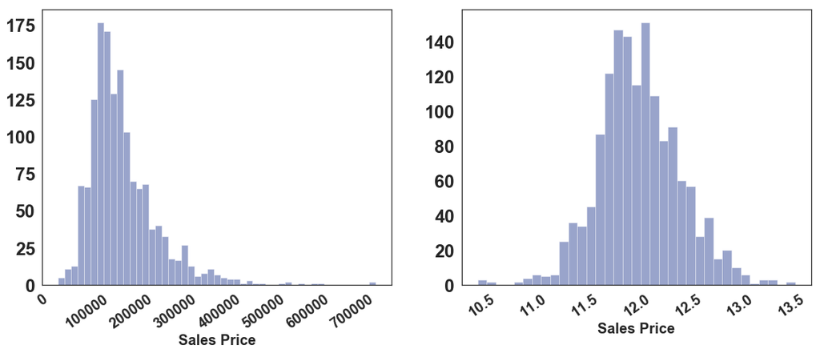

```python
# Compare the distributions of Sale Price versus logged Sale Price.
# The logged Sale Price is more normally distributed.
sns.set(style = "white", palette = "dark")
fig, axs = plt.subplots(ncols=2, figsize = (19,7))
plt.xticks(rotation = 45)
sns.distplot(label, kde = False, rug = False, ax = axs[0])
sns.distplot(logged_label, kde = False, rug = False,  ax = axs[1])

for ax in fig.axes:
    plt.sca(ax)
    plt.xticks(rotation=35, size = 20, fontweight = "bold")
    plt.yticks(size = 25, fontweight = "bold")
    plt.xlabel("Sales Price", size = 20, fontweight = "bold")

plt.show()
```

## Engineered Variables: Total Square-Footage, Total Full Baths, Total Half Baths, and Deck Square-Footage

```python
# Total square-footage of home, including basement sq-footage.
homePrices["totalSqft"] = homePrices["GrLivArea"] + homePrices["TotalBsmtSF"]

#Total Full and Half Baths
homePrices["totalFullBath"] = homePrices["BsmtFullBath"] + homePrices["FullBath"]
homePrices["totalHalfBath"] = homePrices["BsmtHalfBath"] + homePrices["HalfBath"]

# Deck Square-Footage
homePrices["deckPorchSqft"] = (homePrices["WoodDeckSF"] + homePrices["OpenPorchSF"] +
                           homePrices["EnclosedPorch"] + homePrices["3SsnPorch"] +
                           homePrices["ScreenPorch"])

homePricesCleaned = homePrices
```

### One-Hot Encoding

```python
homePricesWithDummies = pd.get_dummies(data = homePrices)

# The MSSubClass variable has several numerical values, however each signify a different categorical class.
# Get dummy variables for the MS SubClass variables.
homePricesMSDummies = pd.get_dummies(data=homePrices["MSSubClass"])
frames = [homePricesWithDummies, homePricesMSDummies]
homePricesWithDummies = pd.concat(frames, axis = 1)
len(homePricesWithDummies)
```

```
2919
```

Feature Filtering We now filter based on how well the variable correlates with Sale Price. We split the training and test sets at this point, and reintroduce SalePrice to the training dataset.

```python
# Rebuild training set
training_cleaned = homePricesWithDummies[homePricesWithDummies["Group_train"]==1]
training_cleaned["loggedSalePrice"] = logged_label

# Rebuild test set
test_cleaned = homePricesWithDummies[homePricesWithDummies["Group_test"]==1]
```

```python
bigger_vars_of_interest = training_cleaned.columns

# Correlation matrix of numerical features
corrmat = training_cleaned[bigger_vars_of_interest].corr()

best_features001 = corrmat[corrmat["loggedSalePrice"] >= 0.0001]
best_features001 = list(best_features001.index)
best_features = corrmat[corrmat["loggedSalePrice"] >= 0.10]
best_features = list(best_features.index)
#best_features
```

```python
best_neg_features001 = corrmat[corrmat["loggedSalePrice"] <= -0.0001]
best_neg_features001 = list(best_neg_features001.index)
best_neg_features = corrmat[corrmat["loggedSalePrice"] <= -0.10]
best_neg_features = list(best_neg_features.index)
#best_neg_features
```

```python
all_best_features = best_features + best_neg_features
all_best_features001 = best_features001 + best_neg_features001
```

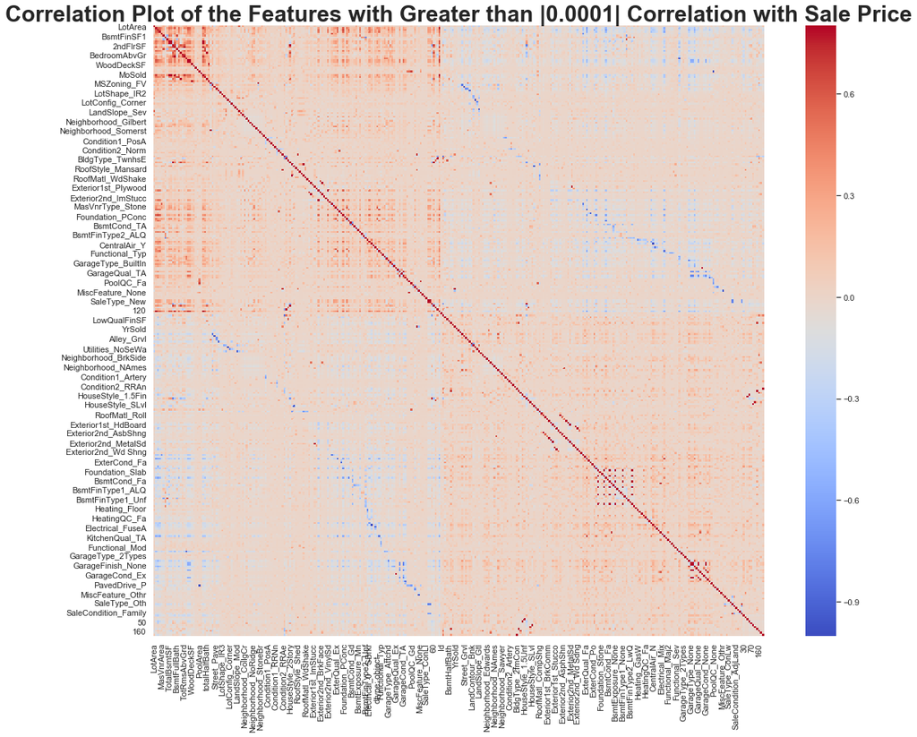

```python
# Correlation matrix of numerical features
corrmat = training_cleaned[all_best_features001].corr()

# Set up the matplotlib figure
f, ax = plt.subplots(figsize = (20, 15))

# Draw the heatmap using seaborn
sns.heatmap(corrmat, vmax = .8, square = True, annot = False, cmap = 'coolwarm')
plt.title("Correlation Plot of the Features with Greater than |0.0001| Correlation with Sale Price", size = 30, fontweight = "bold")
plt.show()
```

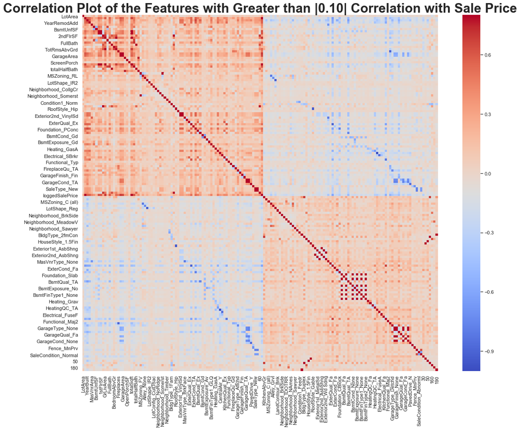

```python
# Correlation matrix of numerical features
corrmat2 = training_cleaned[all_best_features].corr()

# Set up the matplotlib figure
f, ax = plt.subplots(figsize = (20, 15))

# Draw the heatmap using seaborn
sns.heatmap(corrmat2, vmax = .8, square = True, annot = False, cmap = 'coolwarm')
plt.title("Correlation Plot of the Features with Greater than |0.10| Correlation with Sale Price", size = 30, fontweight = 'bold')
plt.show()
```

[figure not shown]

### Find the optimal degree of correlation for inclusion in Linear Models

```python
interval = 0.01
corr_range = np.arange(0,.8,interval)
```

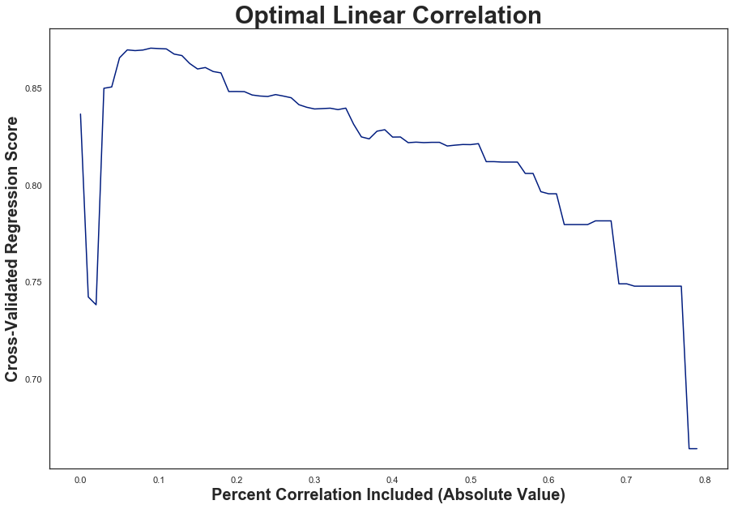

```
The optimal variables for inclusion in the Linear Model is those with correlation of corr = |0.09| and greater.
```

```python
from sklearn.model_selection import cross_val_score
from sklearn import linear_model
from sklearn.model_selection import cross_val_score

regr = linear_model.LinearRegression()

# search for an optimal correlation value for Linear Models
corr_scores = []
for corrVal in corr_range:

    best_features = corrmat[corrmat["loggedSalePrice"] >= corrVal]
    best_features = list(best_features.index)
    best_neg_features = corrmat[corrmat["loggedSalePrice"] <= -corrVal]
    best_neg_features = list(best_neg_features.index)
    current_best_features = best_features + best_neg_features
    current_best_features.remove("loggedSalePrice")
    current_training_cleaned = training_cleaned.drop("loggedSalePrice", axis=1)
    current_training_cleaned.head()
    Y = logged_label
    X = current_training_cleaned[current_best_features]

    regr_score = cross_val_score(regr, X, Y, cv=10)
    corr_scores.append(regr_score.mean())

# plot the value of K for KNN (x-axis) versus the cross-validated accuracy (y-axis)
plt.figure(figsize=(15,10))
plt.plot(corr_range, corr_scores)
plt.xlabel("Percent Correlation Included (Absolute Value)", size = 20, fontweight = "bold")
plt.ylabel("Cross-Validated Regression Score", size = 20, fontweight = "bold")
plt.title("Optimal Linear Correlation", size = 30, fontweight = "bold")
plt.show()

print("The optimal variables for inclusion in the Linear Model is those with correlation of "
      "corr = |{}| and greater.".format(corr_scores.index(max(corr_scores))*interval))
max_linear = corr_scores.index(max(corr_scores))*interval
```

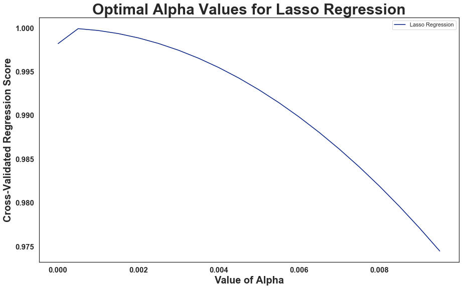

```
The optimal value for alpha in Lasso Regression is 0.0005.
```

```python
from sklearn.model_selection import cross_val_score
from sklearn import linear_model

interval = 0.0005
alpha_range = np.arange(0,0.01,interval)

Y = logged_label
X = training_cleaned[all_best_features001]

# search for an optimal correlation value for Linear Models
lasso_scores = []
for alphaVal in alpha_range:
    lassBig = linear_model.Lasso(alpha=alphaVal)
    lasso_score = cross_val_score(lassBig, X, Y, cv=10)
    lasso_scores.append(lasso_score.mean())

# plot the performance of Lasso and Ridge Regression against the value of alpha
plt.figure(figsize=(15,9))
plt.plot(alpha_range, lasso_scores, label = "Lasso Regression")
plt.xlabel("Value of Alpha", size = 20, fontweight = "bold")
plt.ylabel("Cross-Validated Regression Score", size = 20, fontweight = "bold")
plt.xticks(size = 15, fontweight = "bold")
plt.yticks(size = 15, fontweight = "bold")
plt.legend()
plt.title("Optimal Alpha Values for Lasso Regression", size = 30, fontweight = "bold")
plt.show()

print("The optimal value for alpha in Lasso Regression is {}. ".format(lasso_scores.index(max(lasso_scores))*interval))
best_alpha = lasso_scores.index(max(lasso_scores))*interval
```

```python
# Determined by running a deep and intensive search using the following parameters:
# interval = 0.00001
# alpha_range = np.arange(0,0.005,interval)
# best_alpha = lasso_scores.index(max(lasso_scores))*interval
# Takes ~30 mins to run.
# max(lasso_scores) = 0.87837143492500525

best_alpha_for_Lasso = 0.0006000
```

During the modelling phase, we can't include the "SalePrice" feature in our model except as the target variable.

```python
all_best_features001.remove("loggedSalePrice")
all_best_features.remove("loggedSalePrice")
del training_cleaned["loggedSalePrice"]
```

## Generating Predictive Models

### Linear Regression

```python
from sklearn import linear_model
from sklearn.model_selection import cross_val_score

# Takes the best value from the previous optimization exercise on the correlation value, and
# applies it to this model.
linear_best_features = list((corrmat[corrmat["loggedSalePrice"] >= max_linear]).index) + list(
    (corrmat[corrmat["loggedSalePrice"] <= -max_linear]).index)
linear_best_features.remove("loggedSalePrice")

regr = linear_model.LinearRegression()
Y = logged_label
X = training_cleaned[linear_best_features]
regr.fit(X, Y)

# Inspect the results.
#print('\nCoefficients: \n', regr.coef_)
#print('\nIntercept: \n', regr.intercept_)
print('\nR-squared:')
print(regr.score(X, Y))
```

```
R-squared:
0.913812882493706
```

```python
from sklearn.model_selection import cross_val_score

Y = logged_label
X = training_cleaned[linear_best_features]

regr_score = cross_val_score(regr, X, Y, cv=10)
print("Cross-Validated R-Squared of Linear Regression Model: %0.2f (+/- %0.2f)"
      % (regr_score.mean(), regr_score.std() * 2))
```

```
Cross-Validated R-Squared of Linear Regression Model: 0.87 (+/- 0.12)
```

## LASSO Regression

```python
from sklearn import linear_model
Y = logged_label
X = training_cleaned[all_best_features001]

lassolm = linear_model.Lasso(alpha=best_alpha_for_Lasso, max_iter=10000)
lassolm_score = cross_val_score(lassolm, X, Y, cv=10)
print("Cross-Validated R-Squared of Linear Regression Model: %0.2f (+/- %0.2f)"
      % (lassolm_score.mean(), lassolm_score.std() * 2))
```

```
Cross-Validated R-Squared of Linear Regression Model: 0.88 (+/- 0.18)
```

[figure not shown]

## K-Nearest Neighbors

### Find an optimal k-value by iterating over each value of k

```python
Y = logged_label
X = stats.zscore(training_cleaned[all_best_features])

# search for an optimal unweighted value of K for KNN
k_range = range(1,20)
k_scores = []
for k in k_range:
    knn = neighbors.KNeighborsRegressor(n_neighbors = k)
    scores = cross_val_score(knn, X, Y, cv = 10)
    k_scores.append(scores.mean())

# search for an optimal weighted value of K for KNN
k_range = range(1,20)
k_scores_w = []
for k in k_range:
    knn_w = neighbors.KNeighborsRegressor(n_neighbors = k, weights = 'distance')
    scores_w = cross_val_score(knn_w, X, Y, cv = 10)
    k_scores_w.append(scores_w.mean())
```

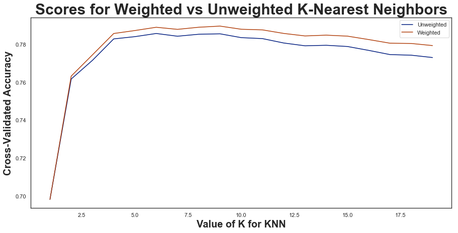

[output not shown]

```python
# plot the value of K for KNN (x-axis) versus the cross-validated accuracy (y-axis)
plt.figure(figsize=(15,7))
plt.plot(k_range, k_scores, label="Unweighted")
plt.plot(k_range, k_scores_w, label="Weighted")
plt.xlabel("Value of K for KNN", size = 20, fontweight = "bold")
plt.ylabel("Cross-Validated Accuracy", size = 20, fontweight = "bold")
plt.legend()
plt.title("Scores for Weighted vs Unweighted K-Nearest Neighbors", size = 30, fontweight = "bold")
plt.show()

print("The optimal value for k (unweighted) is k={}".format(k_scores.index(max(k_scores))+1))
print("The optimal value for k (weighted by distance) is k={}".format(k_scores.index(max(k_scores))+1))
```

```python
# Unweighted KNN (Cross-Validated)
knn = neighbors.KNeighborsRegressor(n_neighbors = 8)
knn_score = cross_val_score(knn, X, Y, cv = 10)
print("KNN Unweighted Mean Score: %0.2f (+/- %0.2f)" % (knn_score.mean(), knn_score.std() * 2))

# Weighted KNN (Cross-Validated)
knn_w = neighbors.KNeighborsRegressor(n_neighbors = 8, weights = 'distance')
knn_w_score = cross_val_score(knn_w, X, Y, cv = 10)
print("KNN Weighted Mean Score: %0.2f (+/- %0.2f)" % (knn_w_score.mean(), knn_w_score.std() * 2))
```

```
KNN Unweighted Mean Score: 0.79 (+/- 0.06)
KNN Weighted Mean Score: 0.79 (+/- 0.05)
```

## Random Forest Regression

```python
from sklearn.ensemble import RandomForestRegressor

rfr = RandomForestRegressor(n_estimators = 500)
X = pd.DataFrame(training_cleaned[all_best_features])
Y = logged_label

rfr_score = cross_val_score(rfr, X, Y, cv = 10)
print("Random Forest: %0.2f (+/- %0.2f)" % (rfr_score.mean(), rfr_score.std() * 2))
```

```
Random Forest: 0.87 (+/- 0.04)
```

```python
rfr.fit(X,Y)
```

```
RandomForestRegressor(bootstrap=True, criterion='mse', max_depth=None,
           max_features='auto', max_leaf_nodes=None,
           min_impurity_decrease=0.0, min_impurity_split=None,
           min_samples_leaf=1, min_samples_split=2,
           min_weight_fraction_leaf=0.0, n_estimators=500, n_jobs=None,
           oob_score=False, random_state=None, verbose=0, warm_start=False)
```

```python
best_predictors = pd.DataFrame(rfr.feature_importances_, X.columns)
best_predictors.columns = {'score'}

sortedFeatures = best_predictors.sort_values('score', ascending="False")
list(sortedFeatures)
sortedFeaturesBest = sortedFeatures[::-1]
sortedFeaturesBest = sortedFeaturesBest[:15]
#sortedFeaturesBest
```

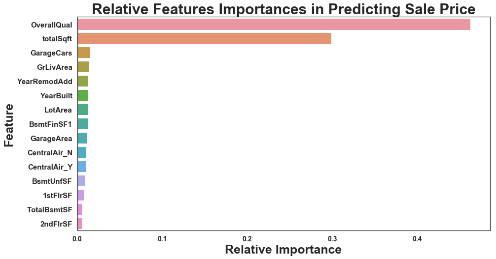

```python
sns.set_style("white")
plt.figure(figsize=(15,8))
sns.barplot(x = sortedFeaturesBest.score, y=sortedFeaturesBest.index)
plt.xlabel("Relative Importance", size = 25, fontweight = "bold")
plt.ylabel("Feature", size = 25, fontweight = "bold")
plt.title("Relative Features Importances in Predicting Sale Price", size = 30, fontweight = "bold")
plt.xticks(rotation = 0, size = 14, fontweight = "bold")
plt.yticks(size = 15, fontweight = "bold")
plt.show()
```

## Decision Tree with AdaBoost

```python
from sklearn.tree import DecisionTreeRegressor
from sklearn.ensemble import AdaBoostRegressor

X = pd.DataFrame(training_cleaned[all_best_features001])
Y = logged_label

# Fit regression model
ada_regr = AdaBoostRegressor(DecisionTreeRegressor(max_depth = 5),
                          n_estimators = 600)

ada_regr_score = cross_val_score(ada_regr, X, Y, cv=10)
print("Decision Tree Regression With AdaBoost: %0.2f (+/- %0.2f)" % (ada_regr_score.mean(), ada_regr_score.std() * 2))
```

```
Decision Tree Regression With AdaBoost: 0.87 (+/- 0.04)
```

```python
ada_regr.fit(X,Y)
```

```
AdaBoostRegressor(base_estimator=DecisionTreeRegressor(criterion='mse', max_depth=5, max_features=None,
           max_leaf_nodes=None, min_impurity_decrease=0.0,
           min_impurity_split=None, min_samples_leaf=1,
           min_samples_split=2, min_weight_fraction_leaf=0.0,
           presort=False, random_state=None, splitter='best'),
         learning_rate=1.0, loss='linear', n_estimators=600,
         random_state=None)
```

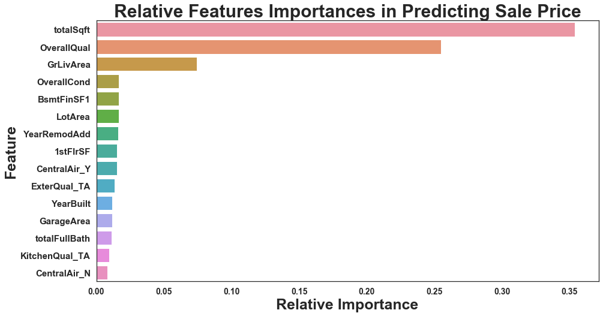

```python
best_predictors = pd.DataFrame(ada_regr.feature_importances_, X.columns)
best_predictors.columns = {'score'}

sortedFeatures = best_predictors.sort_values('score', ascending="False")
list(sortedFeatures)
sortedFeaturesBest = sortedFeatures[::-1]
sortedFeaturesBest = sortedFeaturesBest[:15]
#sortedFeaturesBest

sns.set_style("white")
plt.figure(figsize=(15,8))
sns.barplot(x = sortedFeaturesBest.score, y=sortedFeaturesBest.index)
plt.xlabel("Relative Importance", size = 25, fontweight = "bold")
plt.ylabel("Feature", size = 25, fontweight = "bold")
plt.title("Relative Features Importances in Predicting Sale Price", size = 30, fontweight = "bold")
plt.xticks(rotation = 0, size = 14, fontweight = "bold")
plt.yticks(size = 15, fontweight = "bold")
plt.show()
```

## Gradient Boosting Regression¶

```python
from sklearn.metrics import mean_squared_error
from sklearn.ensemble import GradientBoostingRegressor

X = training_cleaned[linear_best_features]
y = logged_label

gb_regr = GradientBoostingRegressor(n_estimators=500, learning_rate=0.05,
    max_depth=4, loss='ls')

gb_regr_score = cross_val_score(gb_regr, X, y, cv=10)
print("Gradient Boost Regression: %0.2f (+/- %0.2f)" % (gb_regr_score.mean(), gb_regr_score.std() * 2))
```

```
Gradient Boost Regression: 0.90 (+/- 0.03)
```

```python
gb_regr.fit(X,Y)
```

```
GradientBoostingRegressor(alpha=0.9, criterion='friedman_mse', init=None,
             learning_rate=0.05, loss='ls', max_depth=4, max_features=None,
             max_leaf_nodes=None, min_impurity_decrease=0.0,
             min_impurity_split=None, min_samples_leaf=1,
             min_samples_split=2, min_weight_fraction_leaf=0.0,
             n_estimators=500, n_iter_no_change=None, presort='auto',
             random_state=None, subsample=1.0, tol=0.0001,
             validation_fraction=0.1, verbose=0, warm_start=False)
```

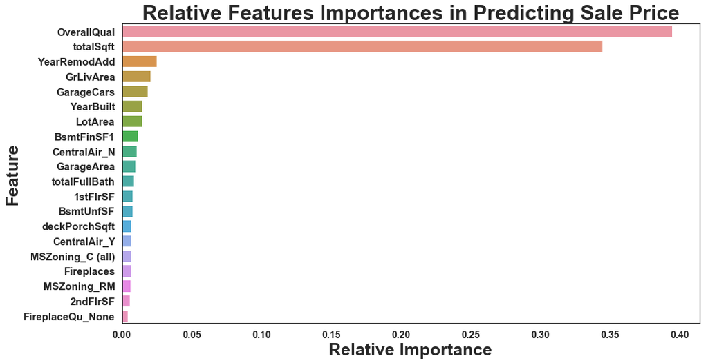

```python
best_predictors = pd.DataFrame(gb_regr.feature_importances_, X.columns)
best_predictors.columns = {'score'}

sortedFeatures = best_predictors.sort_values('score', ascending="False")
list(sortedFeatures)
sortedFeaturesBest = sortedFeatures[::-1]
sortedFeaturesBest = sortedFeaturesBest[:20]
#sortedFeaturesBest

sns.set_style("white")
plt.figure(figsize=(15,8))
sns.barplot(x = sortedFeaturesBest.score, y=sortedFeaturesBest.index)
plt.xlabel("Relative Importance", size = 25, fontweight = "bold")
plt.ylabel("Feature", size = 25, fontweight = "bold")
plt.title("Relative Features Importances in Predicting Sale Price", size = 30, fontweight = "bold")
plt.xticks(rotation = 0, size = 14, fontweight = "bold")
plt.yticks(size = 15, fontweight = "bold")
plt.show()
```

```python
from xgboost import XGBRegressor

xgb = XGBRegressor()

X = pd.DataFrame(training_cleaned[all_best_features])
Y = logged_label

xgb_score = cross_val_score(xgb, X, Y, cv = 10)
print("XGBoost: %0.2f (+/- %0.2f)" % (xgb_score.mean(), xgb_score.std() * 2))

# Add silent=True to avoid printing out updates with each cycle
#my_model.fit(train_X, train_y, verbose=False)
```

```
XGBoost: 0.89 (+/- 0.05)
```

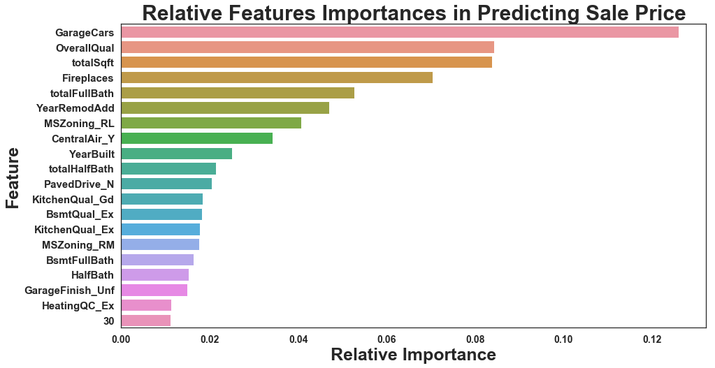

```python
xgb.fit(X, Y)
best_predictors = pd.DataFrame(xgb.feature_importances_, X.columns)
best_predictors.columns = {'score'}

sortedFeatures = best_predictors.sort_values('score', ascending="False")
list(sortedFeatures)
sortedFeaturesBest = sortedFeatures[::-1]
sortedFeaturesBest = sortedFeaturesBest[:20]
#sortedFeaturesBest

sns.set_style("white")
plt.figure(figsize=(15,8))
sns.barplot(x = sortedFeaturesBest.score, y=sortedFeaturesBest.index)
plt.xlabel("Relative Importance", size = 25, fontweight = "bold")
plt.ylabel("Feature", size = 25, fontweight = "bold")
plt.title("Relative Features Importances in Predicting Sale Price", size = 30, fontweight = "bold")
plt.xticks(rotation = 0, size = 14, fontweight = "bold")
plt.yticks(size = 15, fontweight = "bold")
plt.show()
```

## Model Comparision and Discussion

```python
scores = pd.DataFrame()
scores["Gradient Boost"] = gb_regr_score
scores["Lasso Regression"] = lassolm_score
scores["Random Forest"] = rfr_score
scores["Linear Regression"] = regr_score
scores["AdaBoost"] = ada_regr_score
scores["Weighted KNN"] = knn_w_score
scores["KNN"] = knn_score
scores['XGBoost'] = xgb_score

results = pd.DataFrame()
results["Model"] = ('XGBoost Regression', "Linear Regression", "K-Nearest Neighbors (KNN)", "Weighted KNN", "Random Forest",
                    "Decision Tree with AdaBoost", "Gradient Boost", "LASSO Regression")

results["Score"] = (xgb_score.mean(), regr_score.mean(), knn_score.mean(), knn_w_score.mean(), rfr_score.mean(),
                    ada_regr_score.mean(), gb_regr_score.mean(), lassolm_score.mean())
results["Standard Deviation"] = (xgb_score.std(), regr_score.std(), knn_score.std(), knn_w_score.std(), rfr_score.std(),
                                 ada_regr_score.std(), gb_regr_score.std(), lassolm_score.std())

results = results.sort_values(by = 'Score', ascending = False)
results
```

|  | Model | Score | Standard Deviation |
| --- | --- | --- | --- |
| 6 | Gradient Boost | 0.900238 | 0.014657 |
| 0 | XGBoost Regression | 0.889975 | 0.024141 |
| 7 | LASSO Regression | 0.878344 | 0.089969 |
| 4 | Random Forest | 0.874044 | 0.021499 |
| 1 | Linear Regression | 0.870474 | 0.062324 |
| 5 | Decision Tree with AdaBoost | 0.866823 | 0.020607 |
| 3 | Weighted KNN | 0.789037 | 0.027473 |
| 2 | K-Nearest Neighbors (KNN) | 0.785339 | 0.028535 |

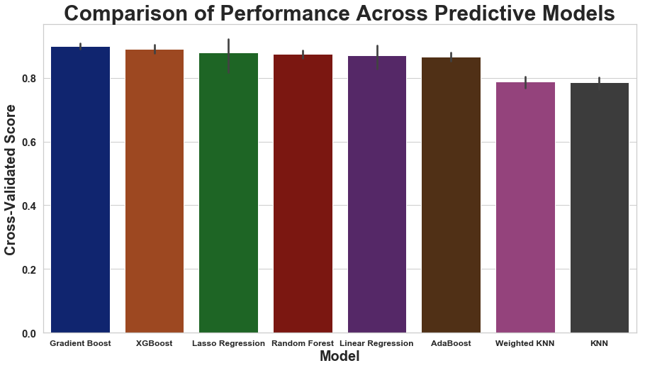

```python
plt.figure(figsize=(15,8))
sns.set_style("whitegrid")
sns.barplot(data=scores, order = scores.mean().sort_values(ascending=False).index)
plt.xlabel("Model", size = 20, fontweight = "bold")
plt.ylabel("Cross-Validated Score", size = 20, fontweight = "bold")
plt.title("Comparison of Performance Across Predictive Models", size = 30, fontweight = "bold")
plt.xticks(rotation = 0, size = 12, fontweight = "bold")
plt.yticks(size = 15, fontweight = "bold")
plt.show()
```

## Interpretation

Each strategy for modelling and predicting data has it's advantages and disadvantages. The goal is to find the method that can most accurately predict the outcome of interest, in this case the Sale Price of the home.

The Random Forest Regression is an ensemble method that helps to improve the outcome from Decision Trees by reducing overfitting. Many trees are created (making a forest, if you will). Each decision tree is seeded with slightly different parameters, and each tree votes for an outcome. The Random Forest performance was high, with low variance.

The Linear Regression and Lasso Regression models score well, however the variance is high in both cases compared to the boosting and ensemble models. This is because only one model is created, compared to boosting and ensemble models where hundreds or even thousands of models are created and combined. The best advantage to Linear and LASSO regressions is that one can obtain coefficients which are easily interpretable to decision-makers. LASSO is an especially good option for datasets with large numbers of variables.

The K-Nearest Neighbors Regression models (Weighted and Unweighted) did not score as well for this dataset, however the variance between cross-validated folds is small. There may be other situations where KNN is a better performer, but it will not be included in our final prediction for this dataset.

## Combine Best Models and Apply to the Test Set

The best performing models can now be combined to create an optimized model. Each model has certain biases, or "blind spots". We combine models built from multiple methods in order to offset biases within each model.

```python
# Top Performing Models
gb_regr.fit(training_cleaned[linear_best_features],Y)
lassolm.fit(training_cleaned[all_best_features001],Y)
rfr.fit(training_cleaned[all_best_features001],Y)
regr.fit(training_cleaned[linear_best_features],Y)
ada_regr.fit(training_cleaned[all_best_features001],Y)

gb_pred = gb_regr.predict(X=test_cleaned[linear_best_features])
lasso_pred = lassolm.predict(X=test_cleaned[all_best_features001])
rfr_pred = rfr.predict(X=test_cleaned[all_best_features001])
regr_pred = regr.predict(X=test_cleaned[linear_best_features])
ada_pred = ada_regr.predict(X=test_cleaned[all_best_features001])

# Take the average of the logged predictions, then return to exponential form.
prediction = np.exp((gb_pred + lasso_pred + rfr_pred + regr_pred + ada_pred) / 5)
predictions = pd.DataFrame(prediction, index = test_cleaned["Id"], columns=["SalePrice"])

# Name output file
predictions.to_csv('/Users/jacquelynzuker/Desktop/rfr_gb_lasso_regr_ada_averaged3.csv')
```

### Where do each of these models get the predictions wrong?

```python
from sklearn.model_selection import train_test_split
X_train, X_test, y_train, y_test = train_test_split(X, y, test_size=0.33, random_state=42)

predictions =  pd.DataFrame()
predictions['actual'] = y_test

rfr.fit(X_train, y_train)
pred = rfr.predict(X_test)
predictions['rfr'] = list(pred)

lassolm.fit(X_train, y_train)
pred = lassolm.predict(X_test)
predictions['lassolm'] = list(pred)

regr.fit(X_train, y_train)
pred = regr.predict(X_test)
predictions['regr'] = list(pred)

ada_regr.fit(X_train, y_train)
pred = ada_regr.predict(X_test)
predictions['ada_regr'] = list(pred)

knn.fit(X_train, y_train)
pred = knn.predict(X_test)
predictions['knn'] = list(pred)

knn_w.fit(X_train, y_train)
pred = knn_w.predict(X_test)
predictions['knn_w'] = list(pred)

xgb.fit(X_train, y_train)
pred = xgb.predict(X_test)
predictions['xgb'] = list(pred)

gb_regr.fit(X_train, y_train)
pred = gb_regr.predict(X_test)
predictions['gb_regr'] = list(pred)
```

```python
dollar_predictions = np.exp(predictions)
dollar_predictions['avg'] = dollar_predictions.loc[:, 'rfr': 'gb_regr'].mean(axis=1)
dollar_predictions['diff'] = dollar_predictions['actual'] - dollar_predictions['avg']
dollar_predictions = dollar_predictions.round(0)
dollar_predictions.head(100)
```

|  | actual | rfr | lassolm | regr | ada_regr | knn | knn_w | xgb | gb_regr | avg | diff |
| --- | --- | --- | --- | --- | --- | --- | --- | --- | --- | --- | --- |
| 892 | 154500.0 | 140557.0 | 145674.0 | 141459.0 | 135876.0 | 135225.0 | 136620.0 | 140761.0 | 140918.0 | 139636.0 | 14864.0 |
| 1105 | 325000.0 | 326815.0 | 322150.0 | 328531.0 | 328182.0 | 325065.0 | 325008.0 | 362568.0 | 338647.0 | 332121.0 | -7121.0 |
| 413 | 115000.0 | 116036.0 | 102107.0 | 99758.0 | 107654.0 | 113311.0 | 114076.0 | 112109.0 | 107735.0 | 109098.0 | 5902.0 |
| 522 | 159000.0 | 149631.0 | 149124.0 | 152727.0 | 150100.0 | 145495.0 | 147613.0 | 143791.0 | 148270.0 | 148344.0 | 10656.0 |
| 1036 | 315500.0 | 303801.0 | 333899.0 | 347750.0 | 320014.0 | 233520.0 | 235727.0 | 309346.0 | 333783.0 | 302230.0 | 13270.0 |
| 614 | 75500.0 | 83621.0 | 86200.0 | 81459.0 | 87245.0 | 89767.0 | 88253.0 | 79379.0 | 77606.0 | 84191.0 | -8691.0 |
| 218 | 311500.0 | 194636.0 | 227822.0 | 232700.0 | 194351.0 | 207735.0 | 205816.0 | 216646.0 | 221008.0 | 212589.0 | 98911.0 |
| 1160 | 146000.0 | 153254.0 | 140250.0 | 134524.0 | 153329.0 | 159793.0 | 151604.0 | 147760.0 | 148991.0 | 148688.0 | -2688.0 |
| 649 | 84500.0 | 82921.0 | 80277.0 | 76137.0 | 84924.0 | 88389.0 | 87409.0 | 77649.0 | 73017.0 | 81340.0 | 3160.0 |
| 887 | 135500.0 | 135039.0 | 140666.0 | 138483.0 | 121280.0 | 148247.0 | 147302.0 | 133161.0 | 132353.0 | 137066.0 | -1566.0 |
| 576 | 145000.0 | 155431.0 | 152464.0 | 152162.0 | 149074.0 | 128349.0 | 126323.0 | 148414.0 | 147151.0 | 144921.0 | 79.0 |
| 1252 | 130000.0 | 118856.0 | 121061.0 | 125187.0 | 118331.0 | 111250.0 | 114331.0 | 122424.0 | 119713.0 | 118894.0 | 11106.0 |
| 1061 | 81000.0 | 103396.0 | 99082.0 | 85706.0 | 102941.0 | 145881.0 | 142118.0 | 109593.0 | 98991.0 | 110963.0 | -29963.0 |
| 567 | 214000.0 | 211041.0 | 212973.0 | 217560.0 | 215939.0 | 214221.0 | 211957.0 | 199448.0 | 194625.0 | 209721.0 | 4279.0 |
| 1108 | 181000.0 | 178380.0 | 170715.0 | 171156.0 | 170720.0 | 168903.0 | 170785.0 | 177711.0 | 171605.0 | 172497.0 | 8503.0 |
| 1113 | 134500.0 | 124635.0 | 135062.0 | 137656.0 | 126114.0 | 132415.0 | 132400.0 | 131407.0 | 123926.0 | 130452.0 | 4048.0 |
| 168 | 183500.0 | 197573.0 | 204703.0 | 200241.0 | 194055.0 | 177638.0 | 177351.0 | 202678.0 | 192949.0 | 193399.0 | -9899.0 |
| 1102 | 135000.0 | 132642.0 | 131473.0 | 134886.0 | 128607.0 | 124975.0 | 126821.0 | 130095.0 | 132404.0 | 130238.0 | 4762.0 |
| 1120 | 118400.0 | 112088.0 | 99032.0 | 94858.0 | 108033.0 | 115667.0 | 117758.0 | 118270.0 | 116062.0 | 110221.0 | 8179.0 |
| 67 | 226000.0 | 211391.0 | 210817.0 | 208185.0 | 235249.0 | 187246.0 | 188063.0 | 209437.0 | 214609.0 | 208125.0 | 17875.0 |
| 1040 | 155000.0 | 173361.0 | 185478.0 | 189003.0 | 164525.0 | 201248.0 | 201364.0 | 168868.0 | 176842.0 | 182586.0 | -27586.0 |
| 453 | 210000.0 | 191664.0 | 212203.0 | 208435.0 | 194701.0 | 178567.0 | 178746.0 | 217914.0 | 212158.0 | 199298.0 | 10702.0 |
| 670 | 173500.0 | 176934.0 | 188404.0 | 190161.0 | 161138.0 | 158609.0 | 159922.0 | 167823.0 | 175384.0 | 172297.0 | 1203.0 |
| 1094 | 129000.0 | 121639.0 | 138873.0 | 140726.0 | 123694.0 | 109411.0 | 108822.0 | 125562.0 | 129270.0 | 124750.0 | 4250.0 |
| 192 | 192000.0 | 200014.0 | 199796.0 | 197474.0 | 222092.0 | 176041.0 | 185534.0 | 201307.0 | 204632.0 | 198361.0 | -6361.0 |
| 123 | 153900.0 | 172593.0 | 154893.0 | 153088.0 | 166803.0 | 154797.0 | 156353.0 | 159994.0 | 168780.0 | 160913.0 | -7013.0 |
| 415 | 181134.0 | 185940.0 | 195651.0 | 193187.0 | 200684.0 | 182203.0 | 182290.0 | 205415.0 | 194942.0 | 192539.0 | -11405.0 |
| 277 | 141000.0 | 106824.0 | 114722.0 | 120123.0 | 100133.0 | 153314.0 | 153275.0 | 113718.0 | 104376.0 | 120810.0 | 20190.0 |
| 433 | 181000.0 | 175885.0 | 177770.0 | 178537.0 | 170521.0 | 175068.0 | 178129.0 | 172487.0 | 176759.0 | 175645.0 | 5355.0 |
| 1317 | 208900.0 | 209482.0 | 201401.0 | 215419.0 | 200769.0 | 176109.0 | 180801.0 | 198659.0 | 200755.0 | 197924.0 | 10976.0 |
| ... | ... | ... | ... | ... | ... | ... | ... | ... | ... | ... | ... |
| 894 | 118858.0 | 116055.0 | 123062.0 | 112303.0 | 114786.0 | 106289.0 | 117947.0 | 118243.0 | 116926.0 | 115701.0 | 3157.0 |
| 1221 | 134000.0 | 136082.0 | 129587.0 | 132715.0 | 127582.0 | 133473.0 | 133463.0 | 126813.0 | 127430.0 | 130893.0 | 3107.0 |
| 427 | 109008.0 | 112368.0 | 113448.0 | 118229.0 | 105120.0 | 116951.0 | 116751.0 | 107441.0 | 111875.0 | 112773.0 | -3765.0 |
| 736 | 93500.0 | 87899.0 | 88323.0 | 85645.0 | 86409.0 | 97451.0 | 93173.0 | 89770.0 | 91110.0 | 89972.0 | 3528.0 |
| 898 | 611657.0 | 415288.0 | 439540.0 | 450234.0 | 447096.0 | 359099.0 | 362943.0 | 233797.0 | 433888.0 | 392736.0 | 218921.0 |
| 682 | 173000.0 | 175931.0 | 196186.0 | 203723.0 | 173445.0 | 159192.0 | 159058.0 | 177466.0 | 189100.0 | 179263.0 | -6263.0 |
| 990 | 348000.0 | 309168.0 | 289121.0 | 289879.0 | 309808.0 | 325542.0 | 327200.0 | 331613.0 | 330092.0 | 314053.0 | 33947.0 |
| 718 | 341000.0 | 303548.0 | 294226.0 | 290531.0 | 289042.0 | 298456.0 | 297403.0 | 327858.0 | 313007.0 | 301759.0 | 39241.0 |
| 44 | 141000.0 | 134282.0 | 139448.0 | 152017.0 | 136167.0 | 130614.0 | 131283.0 | 130884.0 | 132953.0 | 135956.0 | 5044.0 |
| 59 | 124900.0 | 118866.0 | 109666.0 | 110202.0 | 111183.0 | 126030.0 | 126326.0 | 107707.0 | 116289.0 | 115784.0 | 9116.0 |
| 363 | 118000.0 | 100144.0 | 110295.0 | 107020.0 | 101761.0 | 94159.0 | 93381.0 | 105618.0 | 102584.0 | 101870.0 | 16130.0 |
| 398 | 67000.0 | 104950.0 | 71016.0 | 56052.0 | 99767.0 | 118939.0 | 117257.0 | 84510.0 | 91582.0 | 93009.0 | -26009.0 |
| 422 | 113000.0 | 122816.0 | 121159.0 | 127041.0 | 113445.0 | 232432.0 | 221958.0 | 114232.0 | 121305.0 | 146799.0 | -33799.0 |
| 494 | 91300.0 | 97003.0 | 99100.0 | 99128.0 | 98607.0 | 76377.0 | 77736.0 | 101660.0 | 102458.0 | 94009.0 | -2709.0 |
| 416 | 149500.0 | 151247.0 | 151213.0 | 146419.0 | 144471.0 | 171690.0 | 170539.0 | 154848.0 | 155159.0 | 155698.0 | -6198.0 |
| 584 | 133000.0 | 126127.0 | 128733.0 | 131585.0 | 126346.0 | 127257.0 | 127389.0 | 125018.0 | 135882.0 | 128542.0 | 4458.0 |
| 270 | 266000.0 | 254846.0 | 259778.0 | 253549.0 | 247564.0 | 250976.0 | 251056.0 | 261009.0 | 265340.0 | 255515.0 | 10485.0 |
| 351 | 190000.0 | 206311.0 | 207716.0 | 206383.0 | 210286.0 | 265095.0 | 264136.0 | 198033.0 | 200955.0 | 219864.0 | -29864.0 |
| 1078 | 155900.0 | 141095.0 | 146461.0 | 150670.0 | 136903.0 | 130844.0 | 135125.0 | 140793.0 | 142331.0 | 140528.0 | 15372.0 |
| 1344 | 155835.0 | 176536.0 | 203384.0 | 203261.0 | 174741.0 | 176852.0 | 180726.0 | 182253.0 | 179974.0 | 184716.0 | -28881.0 |
| 836 | 153500.0 | 139291.0 | 116774.0 | 122366.0 | 143163.0 | 184508.0 | 182578.0 | 149356.0 | 131443.0 | 146185.0 | 7315.0 |
| 643 | 152000.0 | 151660.0 | 136875.0 | 146279.0 | 152895.0 | 157522.0 | 156286.0 | 140981.0 | 135857.0 | 147295.0 | 4705.0 |
| 274 | 124500.0 | 119841.0 | 128716.0 | 133626.0 | 112394.0 | 126087.0 | 124963.0 | 131172.0 | 124569.0 | 125171.0 | -671.0 |
| 322 | 301000.0 | 281295.0 | 285344.0 | 282563.0 | 272024.0 | 292985.0 | 295471.0 | 284453.0 | 269684.0 | 282977.0 | 18023.0 |
| 78 | 136500.0 | 131503.0 | 103670.0 | 103188.0 | 133582.0 | 198773.0 | 189239.0 | 114102.0 | 108377.0 | 135304.0 | 1196.0 |
| 922 | 169990.0 | 180340.0 | 180549.0 | 183509.0 | 175979.0 | 161234.0 | 163243.0 | 175721.0 | 178901.0 | 174934.0 | -4944.0 |
| 275 | 205000.0 | 159087.0 | 180776.0 | 188518.0 | 164985.0 | 150149.0 | 151688.0 | 187316.0 | 192213.0 | 171842.0 | 33158.0 |
| 1265 | 183900.0 | 165380.0 | 185304.0 | 181087.0 | 166212.0 | 147574.0 | 144119.0 | 173010.0 | 165802.0 | 166061.0 | 17839.0 |
| 220 | 204900.0 | 216288.0 | 198525.0 | 195374.0 | 229582.0 | 184372.0 | 184771.0 | 213363.0 | 215473.0 | 204718.0 | 182.0 |
| 316 | 260000.0 | 233289.0 | 250529.0 | 256132.0 | 244221.0 | 210370.0 | 210996.0 | 237988.0 | 219565.0 | 232886.0 | 27114.0 |

100 rows × 11 columns

[figure not shown]

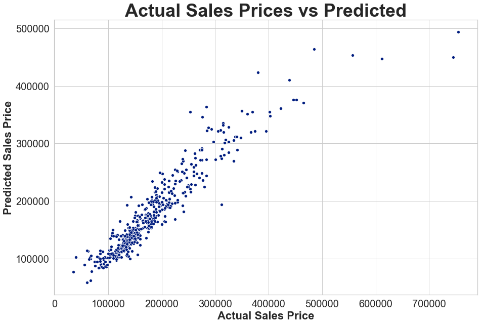

```python
plt.figure(figsize = (15, 10))
sns.scatterplot(dollar_predictions['actual'], dollar_predictions['ada_regr'])
plt.title("Actual Sales Prices vs Predicted", fontweight = 'bold', size = 36)
plt.xlabel('Actual Sales Price', fontweight = 'bold', size = 22)
plt.xticks(size = 20)
plt.ylabel("Predicted Sales Price", fontweight = 'bold', size = 22)
plt.yticks(size = 20)

plt.show()
```

```python
homePricesTrain[homePricesTrain['SalePrice']>500000].sort_values(by="SalePrice").loc[:, 'GarageQual':]
```

|  | GarageQual | GarageCond | PavedDrive | WoodDeckSF | OpenPorchSF | EnclosedPorch | 3SsnPorch | ScreenPorch | PoolArea | PoolQC | Fence | MiscFeature | MiscVal | MoSold | YrSold | SaleType | SaleCondition | SalePrice | Group |
| --- | --- | --- | --- | --- | --- | --- | --- | --- | --- | --- | --- | --- | --- | --- | --- | --- | --- | --- | --- |
| 178 | TA | TA | Y | 0 | 60 | 0 | 0 | 0 | 0 | NaN | NaN | NaN | 0 | 7 | 2009 | New | Partial | 501837 | train |
| 769 | TA | TA | Y | 503 | 36 | 0 | 0 | 210 | 0 | NaN | NaN | NaN | 0 | 6 | 2010 | WD | Normal | 538000 | train |
| 440 | TA | TA | Y | 0 | 72 | 0 | 0 | 170 | 0 | NaN | NaN | NaN | 0 | 4 | 2009 | WD | Normal | 555000 | train |
| 1046 | TA | TA | Y | 214 | 108 | 0 | 0 | 0 | 0 | NaN | NaN | NaN | 0 | 7 | 2006 | New | Partial | 556581 | train |
| 803 | TA | TA | Y | 52 | 170 | 0 | 0 | 192 | 0 | NaN | NaN | NaN | 0 | 1 | 2009 | New | Partial | 582933 | train |
| 898 | TA | TA | Y | 0 | 67 | 0 | 0 | 0 | 0 | NaN | NaN | NaN | 0 | 3 | 2010 | New | Partial | 611657 | train |
| 1169 | TA | TA | Y | 361 | 76 | 0 | 0 | 0 | 0 | NaN | NaN | NaN | 0 | 7 | 2006 | WD | Normal | 625000 | train |
| 1182 | TA | TA | Y | 171 | 78 | 0 | 0 | 0 | 555 | Ex | MnPrv | NaN | 0 | 7 | 2007 | WD | Abnorml | 745000 | train |
| 691 | TA | TA | Y | 382 | 50 | 0 | 0 | 0 | 0 | NaN | NaN | NaN | 0 | 1 | 2007 | WD | Normal | 755000 | train |

SaleCondition: Condition of sale

Normal Normal Sale Abnorml Abnormal Sale - trade, foreclosure, short sale AdjLand Adjoining Land Purchase Alloca Allocation - two linked properties with separate deeds, typically condo with a garage unit  
Family Sale between family members Partial Home was not completed when last assessed (associated with New Homes)

```python
homePricesTrain['SaleCondition'].value_counts()
```

```
Normal     1198
Partial     125
Abnorml     101
Family       20
Alloca       12
AdjLand       4
Name: SaleCondition, dtype: int64
```

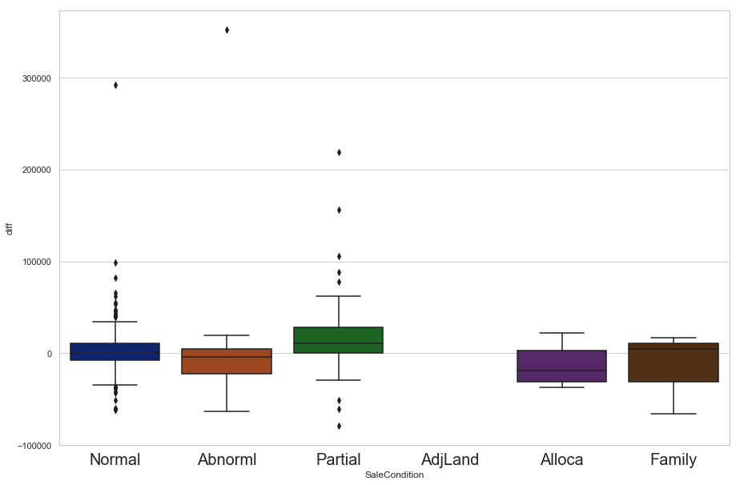

```python
dfSmalls = homePricesTrain['SaleCondition']
dfTogether = pd.concat([dfSmalls, dollar_predictions], axis = 1)

plt.figure(figsize=(15, 10))
sns.boxplot(x = 'SaleCondition', y= 'diff', data = dfTogether)
#plt.title("Actual Sales Prices vs Predicted", fontweight = 'bold', size = 36)
#plt.xlabel('Actual Sales Price', fontweight = 'bold', size = 22)
plt.xticks(size = 20)
#plt.ylabel("Predicted Sales Price", fontweight = 'bold', size = 22)

plt.show()
```